# Insetti in trappola!

2024-03-15

## Il problema degli insetti

Benvenuti e benvenute alla presentazione su come eliminare gli scarafaggi che infestano le nostre case! Nel corso di questa sessione, esploreremo un piano strategico basato sui dati raccolti nel dataset “InsectSprays” in R, con un focus particolare sui maledetti scarafaggi capitalisti che hanno avuto l’ardire di realizzare uno show televisivo, “**Maledetti Scarafaggi**”, che genera guadagni a danno della popolazione generale.

Gli scarafaggi sono una piaga per molte case e possono causare fastidi e preoccupazioni per la salute. Attraverso l’analisi dei dati e l’elaborazione di **strategie efficaci**, esploreremo modi innovativi per sconfiggere questa infestazione una volta per tutte.

[figure not shown]

> *“Non c’è giorno in cui questi maledetti scarafaggi non mi facciano impazzire! Ogni angolo della casa è invaso da loro, è come se avessero un piano ben orchestrato per tormentarmi senza sosta. È ora di porre fine a questa invasione una volta per tutte, prima che prendano il controllo completo della mia casa e della mia sanità mentale!”*

## Il dataset InsectSprays

Il dataset “InsectSprays” contiene dati sperimentali che riguardano l’efficacia di vari insetticidi contro scarafaggi. Permette, quindi, di confrontare l’efficacia dei diversi trattamenti e di identificare l’insetticida più adatto per la specifica situazione. Nello specifico sono stati analizzati diversi **insetticidi spray**:

- *home made*

[figure not shown]

- **esche commestibili**

[figure not shown]

- **stordenti**

[figure not shown]

- **vischiosi**

[figure not shown]

- **americani**

[figure not shown]

- **sonori**

[figure not shown]

## Un po’ di codici

```r
rm(list = ls())

#"Ctrl + Invio" esegue il comando che si trova sulla riga della console oppure
#tutti i comandi contenuti in una selezione di più righe

x <- 10


2 + 2
#in realtà è una funzione, può anche essere scritto come:
'+'(2, 2)


##OPERATORI LOGICI
3 > 4 & 10 < 100 # & AND
10 < 100 | 50 > 2 # | OR

#ESERCIZI 1.1 Operazioni matematiche
((45+21)^3 + 3 / 4)/sqrt(32 - (12 / 17))
(sqrt(7 - pi)) / (3 *(45 - 34))
(12 - (exp(1)^2))^ (1/3) + log(10*pi)
((sin((3/4)*pi)^2)+cos((3/2)*pi))/log(exp(1)^(3/2), base = 7)
sum(1:10)/10

## OGGETTI

2 #numero
"2" #stringa, qualsiasi cosa tra virgolette viene interpretata come stringa
ciao #nome | I nomi vanno prima dichiarati: ciao <- "saluto"

#le stringhe vengono in automatico convertite in un numero che indica
#la posizione delle lettere nell'alfabeto

"a" < "b"
"a" > "b"

#R è case-sensitive quindi le maiuscole e le minuscole non coincidono

"A" == "a"

#ESERCIZI 1.2 Operazioni logiche
(x%%2) == 0 #pari
(x%%2) != 0 #dispari
(x > -4) & (x < -2) | (x > 2) & (x < 4)
4 ^ 3 %in% c(2,3,4) #restituisce false perchè la potenza prevale sull'operatore logico
4 * 3 %in% c(2,3,4) #resctituisce un numero perchè prima viene eseguito l'operatore
#logico la cui risposta è TRUE, il TRUE vale 1, quindi, 4 * 1 = 4
"ciao" == "ciao" #TRUE
"R" == "r" #FALSE
"SPSS" != "SpSS" #TRUE
"1" == 1 #TRUE; quando viene fatto un confronto tra due oggetti incompatibili R tenta
# di trasformare gli oggetti in oggetti compatibili, tendenzialmente viene trasformato
# tutto in stringa
"1" > "ciao" #FALSE; attenzione che qui l'1 è letto come stringa
"a" > "b" # FALSE
"ciao" > "zebra" #FALSE



#SELEZIONE
my_vec <- rnorm(10, mean = 5, sd = 2.5)
my_selection <- my_vec < 2 | my_vec > 8
my_vec[my_selection]

my_vec[my_vec < 2 | my_vec > 8] # in modo più compatto

#posso anche usare la funzione which con la quale posso estrarre le posizioni

whichselection <- which(my_vec < 2 | my_vec > 8)
my_vec[whichselection]
```

## Slide with R Output

```r
summary(cars)
```

```
##      speed           dist
##  Min.   : 4.0   Min.   :  2.00
##  1st Qu.:12.0   1st Qu.: 26.00
##  Median :15.0   Median : 36.00
##  Mean   :15.4   Mean   : 42.98
##  3rd Qu.:19.0   3rd Qu.: 56.00
##  Max.   :25.0   Max.   :120.00
```

## Slide with Plot

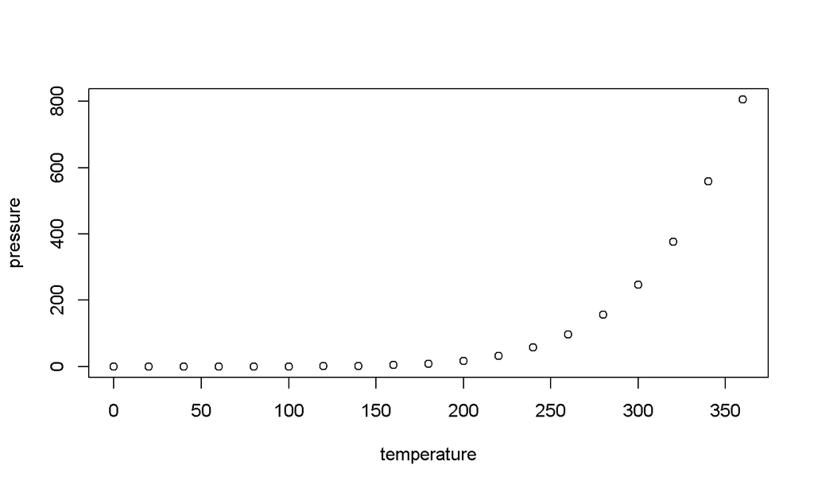